## Importing necessary libraries and data

```python
import numpy as np
from sklearn.linear_model import LinearRegression
import pandas as pd
import matplotlib.pyplot as plt
%matplotlib inline
import seaborn as sns
from sklearn.model_selection import train_test_split # Sklearn package's randomized data splitting function
```

# Problem Summary

The rising potential of this comparatively under-the-radar market fuels the need for an ML-based solution to develop a dynamic pricing strategy for used and refurbished smartphones. ReCell, a startup aiming to tap the potential in this market, has hired you as a data scientist. They want you to analyze the data provided and build a linear regression model to predict the price of a used phone and identify factors that significantly influence it.

# Data Set Overview

The data contains the different attributes of used/refurbished phones. The detailed data dictionary is given below.

brand_name: Name of manufacturing brand\ os: OS on which the phone runs\ screen_size: Size of the screen in cm\ 4g: Whether 4G is available or not\ 5g: Whether 5G is available or not\ main_camera_mp: Resolution of the rear camera in megapixels\ selfie_camera_mp: Resolution of the front camera in megapixels\ int_memory: Amount of internal memory (ROM) in GB\ ram: Amount of RAM in GB\ battery: Energy capacity of the phone battery in mAh\ weight: Weight of the phone in grams\ release_year: Year when the phone model was released\ days_used: Number of days the used/refurbished phone has been used\ new_price: Price of a new phone of the same model in euros\ used_price: Price of the used/refurbished phone in euros\

# Reading Data and Data Overview

The dataset has 3571 rows with 15 columns with 4 categorical column and 11 numerical columns.

```python
df = pd.read_csv("used_phone_data.csv")
df.shape
```

```
(3571, 15)
```

```python
df.dtypes
```

```
brand_name           object
os                   object
screen_size         float64
4g                   object
5g                   object
main_camera_mp      float64
selfie_camera_mp    float64
int_memory          float64
ram                 float64
battery             float64
weight              float64
release_year          int64
days_used             int64
new_price           float64
used_price          float64
dtype: object
```

```python
df.head(10)
```

|  | brand_name | os | screen_size | 4g | 5g | main_camera_mp | selfie_camera_mp | int_memory | ram | battery | weight | release_year | days_used | new_price | used_price |
| --- | --- | --- | --- | --- | --- | --- | --- | --- | --- | --- | --- | --- | --- | --- | --- |
| 0 | Honor | Android | 23.97 | yes | no | 13.0 | 5.0 | 64.0 | 3.0 | 3020.0 | 146.0 | 2020 | 127 | 111.62 | 86.96 |
| 1 | Honor | Android | 28.10 | yes | yes | 13.0 | 16.0 | 128.0 | 8.0 | 4300.0 | 213.0 | 2020 | 325 | 249.39 | 161.49 |
| 2 | Honor | Android | 24.29 | yes | yes | 13.0 | 8.0 | 128.0 | 8.0 | 4200.0 | 213.0 | 2020 | 162 | 359.47 | 268.55 |
| 3 | Honor | Android | 26.04 | yes | yes | 13.0 | 8.0 | 64.0 | 6.0 | 7250.0 | 480.0 | 2020 | 345 | 278.93 | 180.23 |
| 4 | Honor | Android | 15.72 | yes | no | 13.0 | 8.0 | 64.0 | 3.0 | 5000.0 | 185.0 | 2020 | 293 | 140.87 | 103.80 |
| 5 | Honor | Android | 21.43 | yes | no | 13.0 | 8.0 | 64.0 | 4.0 | 4000.0 | 176.0 | 2020 | 223 | 157.70 | 113.67 |
| 6 | Honor | Android | 19.84 | yes | no | 8.0 | 5.0 | 32.0 | 2.0 | 3020.0 | 144.0 | 2020 | 234 | 91.74 | 72.29 |
| 7 | Honor | Android | 18.57 | yes | no | 13.0 | 8.0 | 64.0 | 4.0 | 3400.0 | 164.0 | 2020 | 219 | 179.24 | 132.91 |
| 8 | Honor | Android | 15.72 | yes | no | 13.0 | 16.0 | 128.0 | 6.0 | 4000.0 | 165.0 | 2020 | 161 | 200.32 | 150.88 |
| 9 | Honor | Android | 21.43 | yes | no | 13.0 | 8.0 | 128.0 | 6.0 | 4000.0 | 176.0 | 2020 | 327 | 159.75 | 103.59 |

```python
df.isnull().sum()
```

```
brand_name            0
os                    0
screen_size           0
4g                    0
5g                    0
main_camera_mp      180
selfie_camera_mp      2
int_memory           10
ram                  10
battery               6
weight                7
release_year          0
days_used             0
new_price             0
used_price            0
dtype: int64
```

Box Plot on the Used_price column which will be prediction column . It is evident that there are some outliers on theused_price column

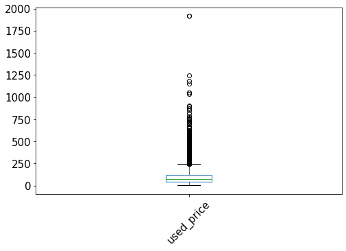

```python
fig, ax = plt.subplots(figsize=(8, 5))
boxplot = df.boxplot(column=['used_price'],grid=False, rot=45, fontsize=15)
```

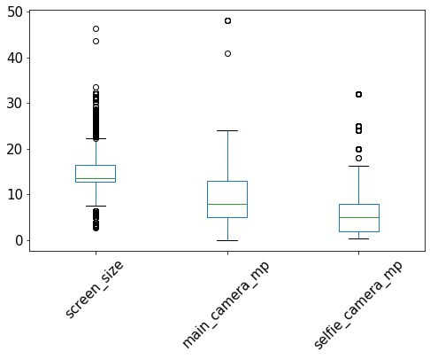

```python
fig, ax = plt.subplots(figsize=(8, 5))
boxplot = df.boxplot(column=['screen_size', 'main_camera_mp','selfie_camera_mp'],grid=False, rot=45, fontsize=15)
```

The outliers might be affected for the other columns also. this has to be investigated later in the notebook

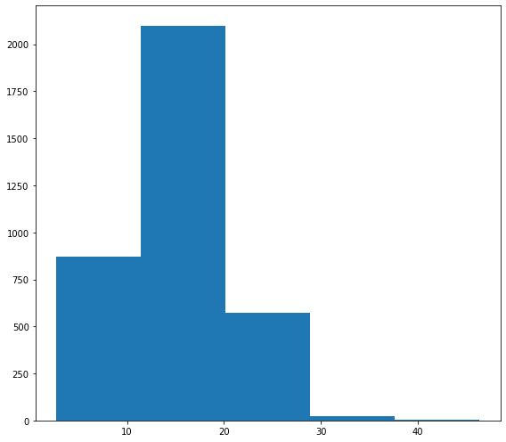

```python
# Creating histogram
fig, axs = plt.subplots(1, 1,
                        figsize =(8, 7),
                        tight_layout = True)

axs.hist(df.screen_size, bins = 5)

# Show plot
plt.show()
```

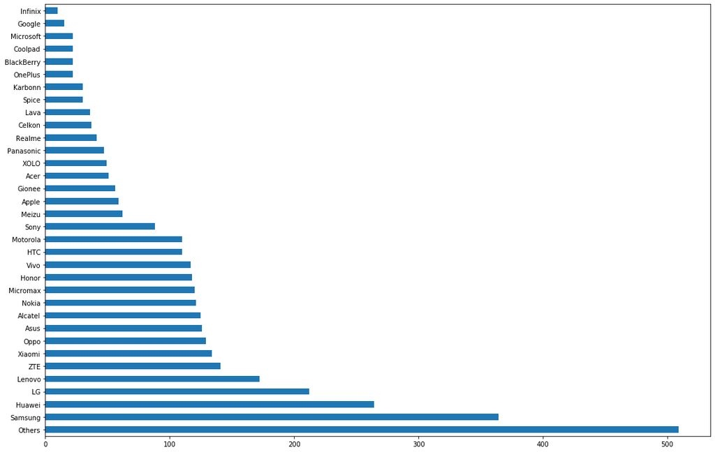

```python
df.brand_name.value_counts().plot(kind='barh',figsize =(18, 12))
```

The brand name others might need to be refilled with possible values

## Exploratory Data Analysis (EDA)

- EDA is an important part of any project involving data.
- It is important to investigate and understand the data better before building a model with it.
- A few questions have been mentioned below which will help you approach the analysis in the right manner and generate insights from the data.
- A thorough analysis of the data, in addition to the questions mentioned below, should be done.

**Questions**:

1. What does the distribution of used phone prices look like?
2. What percentage of the used phone market is dominated by Android devices?
3. The amount of RAM is important for the smooth functioning of a phone. How does the amount of RAM vary with the brand?
4. A large battery often increases a phone's weight, making it feel uncomfortable in the hands. How does the weight vary for phones offering large batteries (more than 4500 mAh)?
5. Bigger screens are desirable for entertainment purposes as they offer a better viewing experience. How many phones are available across different brands with a screen size larger than 6 inches?
6. Budget phones nowadays offer great selfie cameras, allowing us to capture our favorite moments with loved ones. What is the distribution of budget phones offering greater than 8MP selfie cameras across brands?
7. Which attributes are highly correlated with the used phone price?

##### 1.What does the distribution of used phone prices look like?

This is right skewed histogram . Where the mean is 109 and median as 75 and kode is 59.78. But there are ouliers also which is contributing for the high mean value.

```python
df['used_price'].describe()
```

```
count    3571.000000
mean      109.880277
std       121.501226
min         2.510000
25%        45.205000
50%        75.530000
75%       126.000000
max      1916.540000
Name: used_price, dtype: float64
```

```python
print('The mode value of the Used Price  :  ',df['used_price'].mode())
```

```
The mode value of the Used Price  :   0    59.78
dtype: float64
```

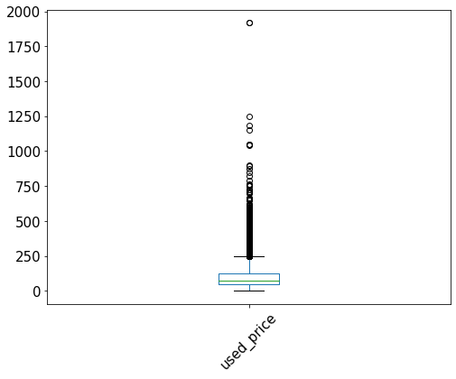

```python
fig, ax = plt.subplots(figsize=(8, 6))
boxplot = df.boxplot(column=['used_price'],grid=False, rot=45, fontsize=15)
```

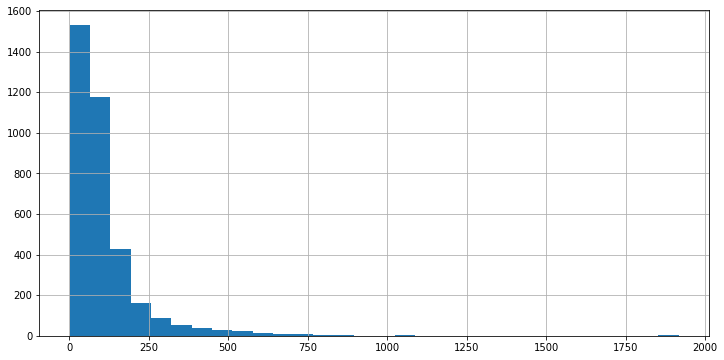

```python
fig, ax = plt.subplots(figsize=(12, 6))
boxplot = df.used_price.hist(bins=30)
```

##### 2. What percentage of the used phone market is dominated by Android devices?

About 90% of market is dominated by the andoriod os and the value of record count 3246

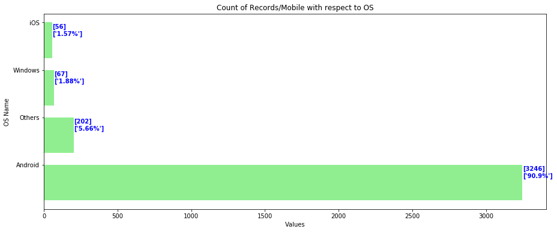

```python
fig, ax = plt.subplots(figsize=(15, 6))
width = 0.75 # the width of the bars
ind = np.arange(len(df.os.value_counts() / len(df.os)))  # the x locations for the groups
ax.barh(ind, df.os.value_counts(), width, color="lightgreen")
ax.set_yticks(ind+width/2)
ax.set_yticklabels(df.os.value_counts().keys(), minor=False)
plt.title('Count of Records/Mobile with respect to OS')
plt.xlabel('Values')
plt.ylabel('OS Name')
for i, v in enumerate(df['os'].value_counts().keys()):
    str1 = round((df[df.os==v].os.value_counts()/len(df.os))*100,2).astype(str) +"%"
    x =df[df.os==v].os.value_counts()
    ax.text(x + 3, i + .1, str(str1.values), color='blue', fontweight='bold')
    ax.text(x + 3, i + .25, str(x.values), color='blue', fontweight='bold')
```

##### 3. The amount of RAM is important for the smooth functioning of a phone. How does the amount of RAM vary with the brand?

no relation between the Ram and the brand name. The scatrerplot doesnt signify any corelation . The most frequent ram is 4 .

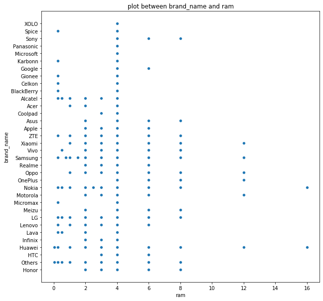

```python
import seaborn as sns
fig, ax = plt.subplots(figsize=(10, 10))
plt.title('plot between brand_name and ram')
plt.xlabel('ram')
plt.ylabel('brand Name')
ax = sns.scatterplot(x="ram",y="brand_name",data=df)
```

##### 4. A large battery often increases a phone's weight, making it feel uncomfortable in the hands. How does the weight vary for phones offering large batteries (more than 4500 mAh)?

The battery and weight are hightly correlated. the increase inlarge batteries increase the weight also. After the 4500mAh , the weight is again correlated to battery.

```python
df[['battery','weight']].corr()
```

|  | battery | weight |
| --- | --- | --- |
| battery | 1.000000 | 0.704468 |
| weight | 0.704468 | 1.000000 |

```python
df1=df[(df.battery >=4500)]
df1[['battery','weight']].corr()
```

|  | battery | weight |
| --- | --- | --- |
| battery | 1.000000 | 0.724347 |
| weight | 0.724347 | 1.000000 |

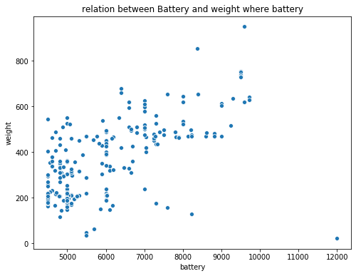

```python
fig, ax = plt.subplots(figsize=(8, 6))
plt.title('relation between Battery and weight where battery')
plt.xlabel('Values')
plt.ylabel('OS Name')
ax = sns.scatterplot(x="battery",y="weight",data=df1)
```

##### 5. Bigger screens are desirable for entertainment purposes as they offer a better viewing experience. How many phones are available across different brands with a screen size larger than 6 inches?

There are 1235 phones greater than 6 imch out of 3571 phones. and the Huawei brand most dominant brand with bigger screen size

```python
df1=df[(df.screen_size >6*2.54)]
```

```python
df1.shape
```

```
(1235, 15)
```

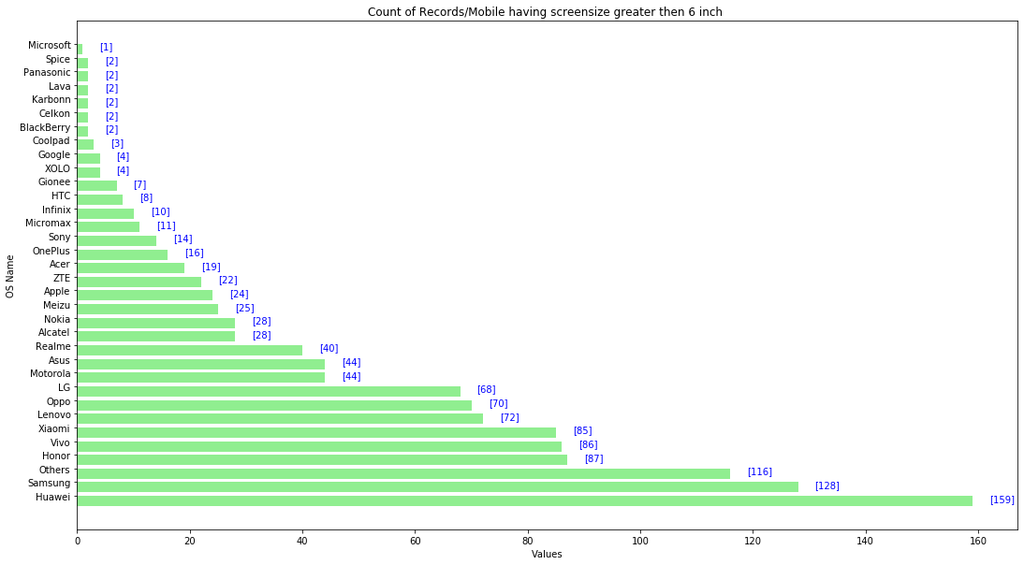

```python
fig, ax = plt.subplots(figsize=(18, 10))
width = 0.75 # the width of the bars
ind = np.arange(len(df1.brand_name.value_counts() / len(df.os)))
ax.barh(ind, df1.brand_name.value_counts(), width, color="lightgreen")
ax.set_yticks(ind+width/2)
ax.set_yticklabels(df1.brand_name.value_counts().keys(), minor=False)
plt.title('Count of Records/Mobile having screensize greater then 6 inch ')
plt.xlabel('Values')
plt.ylabel('OS Name')
for i, v in enumerate(df1['brand_name'].value_counts().keys()):
    x =df1[df1.brand_name==v].brand_name.value_counts()
    ax.text(x + 3, i + .00001, str(x.values), color='blue')
```

##### 6. Budget phones nowadays offer great selfie cameras, allowing us to capture our favorite moments with loved ones. What is the distribution of budget phones offering greater than 8MP selfie cameras across brands?

not any particular pattern , it is distributed acroos the price, there are other factors also deciding the price

```python
df1=df[(df.selfie_camera_mp >8)]
```

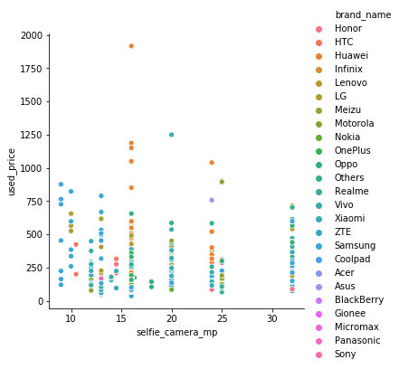

```python
#ax = sns.scatterplot(x="selfie_camera_mp",y="used_price",data=df1)

sns.relplot(
    data=df1, x="selfie_camera_mp", y="used_price",
    hue="brand_name",
    kind="scatter"
)
```

#### 7. Which attributes are highly correlated with the used phone price?

the below columns are positive correlated with used proce. 'int_memory', 'release_year', 'selfie_camera_mp', 'ram', '5g', 'new_price'.

```python
df = pd.read_csv("used_phone_data.csv")
df.shape
```

```
(3571, 15)
```

```python
df["4g"]=df["4g"].map(dict(yes=1, no=0))
df["5g"]=df["5g"].map(dict(yes=1, no=0))

dummy=pd.get_dummies(df["os"])
df=df.merge(dummy,left_index=True,right_index=True)

dummy=pd.get_dummies(df["brand_name"])
df=df.merge(dummy,left_index=True,right_index=True)
```

```python
df1=df
```

```python
df_columns = df.drop(['used_price'], axis=1)
df_used_price = df['used_price']
```

```python
df["4g"].value_counts()
```

```
1    2359
0    1212
Name: 4g, dtype: int64
```

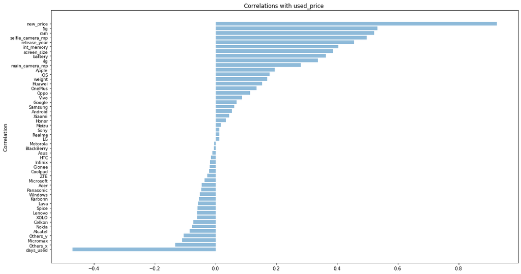

```python
df_corr= df_columns.corrwith(df_used_price)
df_corr.sort_values(inplace=True)
df_corr.index

df_columns.corrwith(df_used_price)

fig, ax = plt.subplots(figsize=(18, 10))
objects = df_corr.index
y_pos = np.arange(len(objects))
# this does not work
# correlation = [corr_open, corr_high, corr_low, corr_close, corr_volume]

plt.barh(df_corr.index, df_corr, align='center', alpha=0.5)
plt.ylabel('Correlation', fontsize=11)
plt.yticks(size = 9)
plt.title('Correlations with used_price ', fontsize=12)

plt.show()
```

## Data Preprocessing

- Missing value treatment
- Feature engineering (if needed)
- Outlier detection and treatment (if needed)
- Preparing data for modeling
- Any other preprocessing steps (if needed)

```python
df = pd.read_csv("used_phone_data.csv")
df.shape
```

```
(3571, 15)
```

##### 1) can compute OS based on the brand name

```python
df.groupby(['brand_name','os']).count()
```

| brand_name | os | screen_size | 4g | 5g | main_camera_mp | selfie_camera_mp | int_memory | ram | battery | weight | release_year | days_used | new_price | used_price |
| --- | --- | --- | --- | --- | --- | --- | --- | --- | --- | --- | --- | --- | --- | --- |
| Acer | Android | 48 | 48 | 48 | 48 | 48 | 48 | 48 | 48 | 48 | 48 | 48 | 48 | 48 |
|  | Others | 1 | 1 | 1 | 1 | 1 | 1 | 1 | 1 | 1 | 1 | 1 | 1 | 1 |
|  | Windows | 2 | 2 | 2 | 2 | 2 | 2 | 2 | 2 | 2 | 2 | 2 | 2 | 2 |
| Alcatel | Android | 110 | 110 | 110 | 110 | 110 | 110 | 110 | 110 | 110 | 110 | 110 | 110 | 110 |
|  | Others | 15 | 15 | 15 | 15 | 15 | 15 | 15 | 15 | 15 | 15 | 15 | 15 | 15 |
| Apple | Others | 3 | 3 | 3 | 3 | 3 | 3 | 3 | 3 | 3 | 3 | 3 | 3 | 3 |
|  | iOS | 56 | 56 | 56 | 56 | 56 | 56 | 56 | 56 | 56 | 56 | 56 | 56 | 56 |
| Asus | Android | 126 | 126 | 126 | 122 | 126 | 126 | 126 | 126 | 126 | 126 | 126 | 126 | 126 |
| BlackBerry | Android | 10 | 10 | 10 | 6 | 10 | 10 | 10 | 10 | 10 | 10 | 10 | 10 | 10 |
|  | Others | 12 | 12 | 12 | 12 | 12 | 12 | 12 | 12 | 12 | 12 | 12 | 12 | 12 |
| Celkon | Android | 22 | 22 | 22 | 22 | 22 | 22 | 22 | 22 | 22 | 22 | 22 | 22 | 22 |
|  | Others | 15 | 15 | 15 | 15 | 15 | 15 | 15 | 15 | 15 | 15 | 15 | 15 | 15 |
| Coolpad | Android | 22 | 22 | 22 | 19 | 22 | 22 | 22 | 22 | 22 | 22 | 22 | 22 | 22 |
| Gionee | Android | 56 | 56 | 56 | 56 | 56 | 56 | 56 | 56 | 56 | 56 | 56 | 56 | 56 |
| Google | Android | 15 | 15 | 15 | 15 | 13 | 15 | 15 | 15 | 15 | 15 | 15 | 15 | 15 |
| HTC | Android | 107 | 107 | 107 | 107 | 107 | 107 | 107 | 107 | 107 | 107 | 107 | 107 | 107 |
|  | Windows | 3 | 3 | 3 | 3 | 3 | 3 | 3 | 3 | 3 | 3 | 3 | 3 | 3 |
| Honor | Android | 116 | 116 | 116 | 116 | 116 | 116 | 116 | 116 | 116 | 116 | 116 | 116 | 116 |
|  | Others | 2 | 2 | 2 | 2 | 2 | 2 | 2 | 2 | 2 | 2 | 2 | 2 | 2 |
| Huawei | Android | 255 | 255 | 255 | 255 | 255 | 255 | 255 | 255 | 255 | 255 | 255 | 255 | 255 |
|  | Others | 7 | 7 | 7 | 7 | 7 | 7 | 7 | 7 | 7 | 7 | 7 | 7 | 7 |
|  | Windows | 2 | 2 | 2 | 2 | 2 | 2 | 2 | 2 | 2 | 2 | 2 | 2 | 2 |
| Infinix | Android | 10 | 10 | 10 | 0 | 10 | 10 | 10 | 10 | 10 | 10 | 10 | 10 | 10 |
| Karbonn | Android | 30 | 30 | 30 | 30 | 30 | 30 | 30 | 30 | 30 | 30 | 30 | 30 | 30 |
| LG | Android | 203 | 203 | 203 | 203 | 203 | 203 | 203 | 203 | 203 | 203 | 203 | 203 | 203 |
|  | Others | 9 | 9 | 9 | 9 | 9 | 9 | 9 | 9 | 9 | 9 | 9 | 9 | 9 |
| Lava | Android | 35 | 35 | 35 | 33 | 35 | 35 | 35 | 35 | 35 | 35 | 35 | 35 | 35 |
|  | Windows | 1 | 1 | 1 | 1 | 1 | 1 | 1 | 1 | 1 | 1 | 1 | 1 | 1 |
| Lenovo | Android | 172 | 172 | 172 | 172 | 172 | 172 | 172 | 172 | 172 | 172 | 172 | 172 | 172 |
| Meizu | Android | 62 | 62 | 62 | 47 | 62 | 62 | 62 | 59 | 62 | 62 | 62 | 62 | 62 |
| Micromax | Android | 107 | 107 | 107 | 107 | 107 | 107 | 107 | 107 | 107 | 107 | 107 | 107 | 107 |
|  | Others | 11 | 11 | 11 | 11 | 11 | 11 | 11 | 11 | 11 | 11 | 11 | 11 | 11 |
|  | Windows | 2 | 2 | 2 | 2 | 2 | 2 | 2 | 2 | 2 | 2 | 2 | 2 | 2 |
| Microsoft | Windows | 22 | 22 | 22 | 22 | 22 | 22 | 22 | 21 | 22 | 22 | 22 | 22 | 22 |
| Motorola | Android | 110 | 110 | 110 | 92 | 110 | 110 | 110 | 110 | 110 | 110 | 110 | 110 | 110 |
| Nokia | Android | 46 | 46 | 46 | 46 | 46 | 46 | 46 | 46 | 46 | 46 | 46 | 46 | 46 |
|  | Others | 54 | 54 | 54 | 54 | 54 | 44 | 44 | 52 | 54 | 54 | 54 | 54 | 54 |
|  | Windows | 21 | 21 | 21 | 21 | 21 | 21 | 21 | 21 | 21 | 21 | 21 | 21 | 21 |
| OnePlus | Android | 22 | 22 | 22 | 5 | 22 | 22 | 22 | 22 | 22 | 22 | 22 | 22 | 22 |
| Oppo | Android | 129 | 129 | 129 | 109 | 129 | 129 | 129 | 129 | 129 | 129 | 129 | 129 | 129 |
| Others | Android | 466 | 466 | 466 | 466 | 466 | 466 | 466 | 466 | 466 | 466 | 466 | 466 | 466 |
|  | Others | 34 | 34 | 34 | 34 | 34 | 34 | 34 | 34 | 34 | 34 | 34 | 34 | 34 |
|  | Windows | 9 | 9 | 9 | 9 | 9 | 9 | 9 | 9 | 9 | 9 | 9 | 9 | 9 |
| Panasonic | Android | 47 | 47 | 47 | 45 | 47 | 47 | 47 | 47 | 47 | 47 | 47 | 47 | 47 |
| Realme | Android | 41 | 41 | 41 | 5 | 41 | 41 | 41 | 41 | 41 | 41 | 41 | 41 | 41 |
| Samsung | Android | 325 | 325 | 325 | 325 | 325 | 325 | 325 | 325 | 325 | 325 | 325 | 325 | 325 |
|  | Others | 36 | 36 | 36 | 36 | 36 | 36 | 36 | 36 | 36 | 36 | 36 | 36 | 36 |
|  | Windows | 3 | 3 | 3 | 3 | 3 | 3 | 3 | 3 | 3 | 3 | 3 | 3 | 3 |
| Sony | Android | 88 | 88 | 88 | 81 | 88 | 88 | 88 | 88 | 88 | 88 | 88 | 88 | 88 |
| Spice | Android | 30 | 30 | 30 | 30 | 30 | 30 | 30 | 30 | 30 | 30 | 30 | 30 | 30 |
| Vivo | Android | 117 | 117 | 117 | 103 | 117 | 117 | 117 | 117 | 117 | 117 | 117 | 117 | 117 |
| XOLO | Android | 47 | 47 | 47 | 47 | 47 | 47 | 47 | 47 | 41 | 47 | 47 | 47 | 47 |
|  | Windows | 2 | 2 | 2 | 2 | 2 | 2 | 2 | 2 | 1 | 2 | 2 | 2 | 2 |
| Xiaomi | Android | 132 | 132 | 132 | 109 | 132 | 132 | 132 | 132 | 132 | 132 | 132 | 132 | 132 |
|  | Others | 2 | 2 | 2 | 1 | 2 | 2 | 2 | 2 | 2 | 2 | 2 | 2 | 2 |
| ZTE | Android | 140 | 140 | 140 | 136 | 140 | 140 | 140 | 140 | 140 | 140 | 140 | 140 | 140 |
|  | Others | 1 | 1 | 1 | 1 | 1 | 1 | 1 | 1 | 1 | 1 | 1 | 1 | 1 |

```python
df['os'][(df['brand_name'] == 'ZTE' ) &  (df['os'] == 'Others') ]  ='Android'
df['os'][(df['brand_name'] == 'Xiaomi' ) &  (df['os'] == 'Others') ]  ='Android'
df['os'][(df['brand_name'] == 'Honor' ) &  (df['os'] == 'Others') ]  ='Android'
df['os'][(df['brand_name'] == 'Alcatel' ) &  (df['os'] == 'Others') ]  ='Android'
df['os'][(df['brand_name'] == 'Celkon' ) &  (df['os'] == 'Others') ]  ='Android'
df['os'][(df['brand_name'] == 'BlackBerry' ) &  (df['os'] == 'Others') ]  ='Android'
df['os'][(df['brand_name'] == 'Apple' ) &  (df['os'] == 'Others') ]  ='iOS'
```

[output not shown]

```python
df.groupby(['brand_name','os']).count()
```

| brand_name | os | screen_size | 4g | 5g | main_camera_mp | selfie_camera_mp | int_memory | ram | battery | weight | release_year | days_used | new_price | used_price |
| --- | --- | --- | --- | --- | --- | --- | --- | --- | --- | --- | --- | --- | --- | --- |
| Acer | Android | 48 | 48 | 48 | 48 | 48 | 48 | 48 | 48 | 48 | 48 | 48 | 48 | 48 |
|  | Others | 1 | 1 | 1 | 1 | 1 | 1 | 1 | 1 | 1 | 1 | 1 | 1 | 1 |
|  | Windows | 2 | 2 | 2 | 2 | 2 | 2 | 2 | 2 | 2 | 2 | 2 | 2 | 2 |
| Alcatel | Android | 125 | 125 | 125 | 125 | 125 | 125 | 125 | 125 | 125 | 125 | 125 | 125 | 125 |
| Apple | iOS | 59 | 59 | 59 | 59 | 59 | 59 | 59 | 59 | 59 | 59 | 59 | 59 | 59 |
| Asus | Android | 126 | 126 | 126 | 122 | 126 | 126 | 126 | 126 | 126 | 126 | 126 | 126 | 126 |
| BlackBerry | Android | 22 | 22 | 22 | 18 | 22 | 22 | 22 | 22 | 22 | 22 | 22 | 22 | 22 |
| Celkon | Android | 37 | 37 | 37 | 37 | 37 | 37 | 37 | 37 | 37 | 37 | 37 | 37 | 37 |
| Coolpad | Android | 22 | 22 | 22 | 19 | 22 | 22 | 22 | 22 | 22 | 22 | 22 | 22 | 22 |
| Gionee | Android | 56 | 56 | 56 | 56 | 56 | 56 | 56 | 56 | 56 | 56 | 56 | 56 | 56 |
| Google | Android | 15 | 15 | 15 | 15 | 13 | 15 | 15 | 15 | 15 | 15 | 15 | 15 | 15 |
| HTC | Android | 107 | 107 | 107 | 107 | 107 | 107 | 107 | 107 | 107 | 107 | 107 | 107 | 107 |
|  | Windows | 3 | 3 | 3 | 3 | 3 | 3 | 3 | 3 | 3 | 3 | 3 | 3 | 3 |
| Honor | Android | 118 | 118 | 118 | 118 | 118 | 118 | 118 | 118 | 118 | 118 | 118 | 118 | 118 |
| Huawei | Android | 255 | 255 | 255 | 255 | 255 | 255 | 255 | 255 | 255 | 255 | 255 | 255 | 255 |
|  | Others | 7 | 7 | 7 | 7 | 7 | 7 | 7 | 7 | 7 | 7 | 7 | 7 | 7 |
|  | Windows | 2 | 2 | 2 | 2 | 2 | 2 | 2 | 2 | 2 | 2 | 2 | 2 | 2 |
| Infinix | Android | 10 | 10 | 10 | 0 | 10 | 10 | 10 | 10 | 10 | 10 | 10 | 10 | 10 |
| Karbonn | Android | 30 | 30 | 30 | 30 | 30 | 30 | 30 | 30 | 30 | 30 | 30 | 30 | 30 |
| LG | Android | 203 | 203 | 203 | 203 | 203 | 203 | 203 | 203 | 203 | 203 | 203 | 203 | 203 |
|  | Others | 9 | 9 | 9 | 9 | 9 | 9 | 9 | 9 | 9 | 9 | 9 | 9 | 9 |
| Lava | Android | 35 | 35 | 35 | 33 | 35 | 35 | 35 | 35 | 35 | 35 | 35 | 35 | 35 |
|  | Windows | 1 | 1 | 1 | 1 | 1 | 1 | 1 | 1 | 1 | 1 | 1 | 1 | 1 |
| Lenovo | Android | 172 | 172 | 172 | 172 | 172 | 172 | 172 | 172 | 172 | 172 | 172 | 172 | 172 |
| Meizu | Android | 62 | 62 | 62 | 47 | 62 | 62 | 62 | 59 | 62 | 62 | 62 | 62 | 62 |
| Micromax | Android | 107 | 107 | 107 | 107 | 107 | 107 | 107 | 107 | 107 | 107 | 107 | 107 | 107 |
|  | Others | 11 | 11 | 11 | 11 | 11 | 11 | 11 | 11 | 11 | 11 | 11 | 11 | 11 |
|  | Windows | 2 | 2 | 2 | 2 | 2 | 2 | 2 | 2 | 2 | 2 | 2 | 2 | 2 |
| Microsoft | Windows | 22 | 22 | 22 | 22 | 22 | 22 | 22 | 21 | 22 | 22 | 22 | 22 | 22 |
| Motorola | Android | 110 | 110 | 110 | 92 | 110 | 110 | 110 | 110 | 110 | 110 | 110 | 110 | 110 |
| Nokia | Android | 46 | 46 | 46 | 46 | 46 | 46 | 46 | 46 | 46 | 46 | 46 | 46 | 46 |
|  | Others | 54 | 54 | 54 | 54 | 54 | 44 | 44 | 52 | 54 | 54 | 54 | 54 | 54 |
|  | Windows | 21 | 21 | 21 | 21 | 21 | 21 | 21 | 21 | 21 | 21 | 21 | 21 | 21 |
| OnePlus | Android | 22 | 22 | 22 | 5 | 22 | 22 | 22 | 22 | 22 | 22 | 22 | 22 | 22 |
| Oppo | Android | 129 | 129 | 129 | 109 | 129 | 129 | 129 | 129 | 129 | 129 | 129 | 129 | 129 |
| Others | Android | 466 | 466 | 466 | 466 | 466 | 466 | 466 | 466 | 466 | 466 | 466 | 466 | 466 |
|  | Others | 34 | 34 | 34 | 34 | 34 | 34 | 34 | 34 | 34 | 34 | 34 | 34 | 34 |
|  | Windows | 9 | 9 | 9 | 9 | 9 | 9 | 9 | 9 | 9 | 9 | 9 | 9 | 9 |
| Panasonic | Android | 47 | 47 | 47 | 45 | 47 | 47 | 47 | 47 | 47 | 47 | 47 | 47 | 47 |
| Realme | Android | 41 | 41 | 41 | 5 | 41 | 41 | 41 | 41 | 41 | 41 | 41 | 41 | 41 |
| Samsung | Android | 325 | 325 | 325 | 325 | 325 | 325 | 325 | 325 | 325 | 325 | 325 | 325 | 325 |
|  | Others | 36 | 36 | 36 | 36 | 36 | 36 | 36 | 36 | 36 | 36 | 36 | 36 | 36 |
|  | Windows | 3 | 3 | 3 | 3 | 3 | 3 | 3 | 3 | 3 | 3 | 3 | 3 | 3 |
| Sony | Android | 88 | 88 | 88 | 81 | 88 | 88 | 88 | 88 | 88 | 88 | 88 | 88 | 88 |
| Spice | Android | 30 | 30 | 30 | 30 | 30 | 30 | 30 | 30 | 30 | 30 | 30 | 30 | 30 |
| Vivo | Android | 117 | 117 | 117 | 103 | 117 | 117 | 117 | 117 | 117 | 117 | 117 | 117 | 117 |
| XOLO | Android | 47 | 47 | 47 | 47 | 47 | 47 | 47 | 47 | 41 | 47 | 47 | 47 | 47 |
|  | Windows | 2 | 2 | 2 | 2 | 2 | 2 | 2 | 2 | 1 | 2 | 2 | 2 | 2 |
| Xiaomi | Android | 134 | 134 | 134 | 110 | 134 | 134 | 134 | 134 | 134 | 134 | 134 | 134 | 134 |
| ZTE | Android | 141 | 141 | 141 | 137 | 141 | 141 | 141 | 141 | 141 | 141 | 141 | 141 | 141 |

#### 2) Outliers Treatment

```python
print('0.75 percentile of used_price is' , df['used_price'].quantile(0.75))
print('0.85 percentile of used_price is' , df['used_price'].quantile(0.85))
print('0.90 percentile of used_price is' , df['used_price'].quantile(0.90))
print('0.91 percentile of used_price is' , df['used_price'].quantile(0.91))
print('0.92 percentile of used_price is' , df['used_price'].quantile(0.92))
print('0.93 percentile of used_price is' , df['used_price'].quantile(0.93))
print('0.94 percentile of used_price is' , df['used_price'].quantile(0.94))
print('0.95 percentile of used_price is' , df['used_price'].quantile(0.95))
print('0.96 percentile of used_price is' , df['used_price'].quantile(0.96))
print('0.97 percentile of used_price is' , df['used_price'].quantile(0.97))
print('0.98 percentile of used_price is' , df['used_price'].quantile(0.98))
```

```
0.75 percentile of used_price is 126.0
0.85 percentile of used_price is 170.06
0.90 percentile of used_price is 209.6
0.91 percentile of used_price is 224.72800000000015
0.92 percentile of used_price is 248.44800000000004
0.93 percentile of used_price is 268.2350000000001
0.94 percentile of used_price is 291.6439999999997
0.95 percentile of used_price is 323.985
0.96 percentile of used_price is 359.9279999999997
0.97 percentile of used_price is 414.5930000000001
0.98 percentile of used_price is 485.39599999999916
```

```python
df = df[(df['used_price'] < 600)]
```

#### 2) Map the null values with mean values

```python
def replace_mean(column_name,brand_name,value):
        df[column_name][(df[column_name].isnull()) & (df['brand_name'] ==brand_name) ] = value
        print("Replaced the column null value ",column_name ," for the brand " ,brand_name ," With Value " ,value )

#df[(df['main_camera_mp'].isnull()) & (df['brand_name'] =='Acer') ]
```

```python
df.isnull().sum()
```

```
brand_name            0
os                    0
screen_size           0
4g                    0
5g                    0
main_camera_mp      172
selfie_camera_mp      2
int_memory           10
ram                  10
battery               6
weight                7
release_year          0
days_used             0
new_price             0
used_price            0
dtype: int64
```

#### Column : main_camera_mp null. value computation

The Infinix has all the records with main_camera_mp as null . Updaing the value with 16.0

```python
df['main_camera_mp'][(df['main_camera_mp'].isnull()) & (df['brand_name'] =='Infinix') ] =16.0
```

the values are computed based on the mean value

```python
df.groupby('brand_name').agg({'main_camera_mp': lambda x: (x.isnull().sum(),x.mean())})
```

| brand_name | main_camera_mp |
| --- | --- |
| Acer | (0, 6.9676470588235295) |
| Alcatel | (0, 6.324799999999998) |
| Apple | (0, 9.907407407407407) |
| Asus | (3, 10.009426229508197) |
| BlackBerry | (4, 10.333333333333334) |
| Celkon | (0, 3.597297297297297) |
| Coolpad | (3, 11.263157894736842) |
| Gionee | (0, 9.913392857142856) |
| Google | (0, 11.93333333333333) |
| HTC | (0, 10.792727272727273) |
| Honor | (0, 12.338983050847459) |
| Huawei | (0, 10.318750000000003) |
| Infinix | (0, 16.0) |
| Karbonn | (0, 6.796666666666668) |
| LG | (0, 8.409808612440195) |
| Lava | (2, 6.845588235294119) |
| Lenovo | (0, 8.94622093023256) |
| Meizu | (15, 13.608510638297876) |
| Micromax | (0, 5.9737499999999955) |
| Microsoft | (0, 9.454545454545455) |
| Motorola | (16, 12.869565217391305) |
| Nokia | (0, 5.576528925619835) |
| OnePlus | (17, 14.2) |
| Oppo | (17, 10.46712962962963) |
| Others | (0, 7.916168958742639) |
| Panasonic | (2, 10.427777777777777) |
| Realme | (36, 13.0) |
| Samsung | (0, 9.09817415730338) |
| Sony | (5, 14.703703703703706) |
| Spice | (0, 4.921666666666668) |
| Vivo | (14, 12.859223300970873) |
| XOLO | (0, 7.4551020408163255) |
| Xiaomi | (24, 12.399082568807339) |
| ZTE | (4, 11.705109489051097) |

```python
replace_mean('main_camera_mp','Asus',10) ## will replace for 4 records
replace_mean('main_camera_mp','BlackBerry',10) ## will replace for 4 records
replace_mean('main_camera_mp','Coolpad',12) ## will replace for 3 records
replace_mean('main_camera_mp','Lava',7) ## will replace for 2 records
replace_mean('main_camera_mp','Meizu',14) ## will replace for 15 records
replace_mean('main_camera_mp','Motorola',13) ## will replace for 16 records
replace_mean('main_camera_mp','OnePlus',14) ## will replace for 17 records
replace_mean('main_camera_mp','Oppo',10) ## will replace for 20 records
replace_mean('main_camera_mp','Panasonic',10) ## will replace for 2 records
replace_mean('main_camera_mp','Realme',13) ## will replace for 36 records
replace_mean('main_camera_mp','Sony',15) ## will replace for 36 records
replace_mean('main_camera_mp','Vivo',13) ## will replace for 14 records
replace_mean('main_camera_mp','Xiaomi',13) ## will replace for 24 records
replace_mean('main_camera_mp','ZTE',12) ## will replace for 4 records
```

```
Replaced the column null value  main_camera_mp  for the brand  Asus  With Value  10
Replaced the column null value  main_camera_mp  for the brand  BlackBerry  With Value  10
Replaced the column null value  main_camera_mp  for the brand  Coolpad  With Value  12
Replaced the column null value  main_camera_mp  for the brand  Lava  With Value  7
Replaced the column null value  main_camera_mp  for the brand  Meizu  With Value  14
Replaced the column null value  main_camera_mp  for the brand  Motorola  With Value  13
Replaced the column null value  main_camera_mp  for the brand  OnePlus  With Value  14
Replaced the column null value  main_camera_mp  for the brand  Oppo  With Value  10
Replaced the column null value  main_camera_mp  for the brand  Panasonic  With Value  10
Replaced the column null value  main_camera_mp  for the brand  Realme  With Value  13
Replaced the column null value  main_camera_mp  for the brand  Sony  With Value  15
Replaced the column null value  main_camera_mp  for the brand  Vivo  With Value  13
Replaced the column null value  main_camera_mp  for the brand  Xiaomi  With Value  13
Replaced the column null value  main_camera_mp  for the brand  ZTE  With Value  12
```

```python
df['main_camera_mp'].isnull().sum()
```

```
0
```

```python
df.groupby("brand_name").mean()
```

| brand_name | screen_size | main_camera_mp | selfie_camera_mp | int_memory | ram | battery | weight | release_year | days_used | new_price | used_price |
| --- | --- | --- | --- | --- | --- | --- | --- | --- | --- | --- | --- |
| Acer | 15.245490 | 6.967647 | 2.474510 | 23.215686 | 3.901961 | 2999.607843 | 225.872549 | 2014.372549 | 795.921569 | 172.867647 | 63.798431 |
| Alcatel | 13.128480 | 6.324800 | 2.260800 | 36.224000 | 3.426000 | 2393.360000 | 166.465600 | 2014.976000 | 752.632000 | 142.499092 | 55.326080 |
| Apple | 15.921111 | 9.907407 | 4.718519 | 74.370370 | 3.925926 | 3484.555556 | 219.953704 | 2016.407407 | 670.611111 | 587.042806 | 256.463889 |
| Asus | 15.433440 | 10.009200 | 4.377600 | 50.048000 | 4.016000 | 3379.128000 | 215.135200 | 2015.344000 | 749.960000 | 243.697556 | 98.539120 |
| BlackBerry | 12.410909 | 10.272727 | 5.140909 | 57.454545 | 3.829545 | 2822.500000 | 160.568182 | 2015.181818 | 692.909091 | 234.774545 | 102.039091 |
| Celkon | 9.554054 | 3.597297 | 0.635135 | 219.675676 | 1.466216 | 1459.459459 | 135.202703 | 2013.243243 | 801.405405 | 60.956486 | 22.648378 |
| Coolpad | 14.040000 | 11.363636 | 7.181818 | 36.363636 | 3.954545 | 2945.000000 | 154.381818 | 2016.363636 | 766.227273 | 194.285455 | 77.928182 |
| Gionee | 13.620536 | 9.913393 | 5.160714 | 43.714286 | 3.933036 | 3117.946429 | 161.476786 | 2014.928571 | 782.642857 | 255.379286 | 91.881964 |
| Google | 15.060000 | 11.933333 | 7.538462 | 57.600000 | 4.533333 | 3628.333333 | 187.733333 | 2017.933333 | 519.200000 | 474.716667 | 239.211333 |
| HTC | 12.966364 | 10.792727 | 5.740909 | 33.018182 | 4.000000 | 2614.454545 | 155.247273 | 2015.172727 | 756.818182 | 249.853818 | 99.626000 |
| Honor | 19.046102 | 12.338983 | 11.718644 | 74.644068 | 4.593220 | 3635.677966 | 177.488136 | 2018.161017 | 465.601695 | 235.897915 | 132.285932 |
| Huawei | 16.950430 | 10.318750 | 10.152344 | 67.687500 | 4.536367 | 3559.152344 | 198.514453 | 2017.101562 | 565.269531 | 274.627125 | 142.083281 |
| Infinix | 18.478000 | 16.000000 | 11.200000 | 38.400000 | 2.600000 | 4800.000000 | 184.400000 | 2019.600000 | 313.300000 | 106.017000 | 68.979000 |
| Karbonn | 11.683667 | 6.796667 | 1.823333 | 65.600333 | 3.375000 | 1730.000000 | 137.933333 | 2013.366667 | 820.066667 | 110.384333 | 38.069333 |
| LG | 13.656986 | 8.409809 | 5.095215 | 34.909091 | 3.854067 | 2894.162679 | 164.683493 | 2015.866029 | 673.368421 | 231.715833 | 108.004545 |
| Lava | 12.465278 | 6.854167 | 2.419444 | 104.000000 | 3.277778 | 2248.611111 | 140.408333 | 2014.527778 | 787.222222 | 107.424722 | 40.112778 |
| Lenovo | 16.110000 | 8.946221 | 5.158140 | 42.232558 | 3.886628 | 3653.255814 | 227.841279 | 2015.610465 | 724.767442 | 193.358779 | 77.147500 |
| Meizu | 15.221129 | 13.703226 | 10.629032 | 58.580645 | 4.451613 | 3368.220339 | 160.790323 | 2017.177419 | 657.032258 | 269.569242 | 126.515484 |
| Micromax | 12.176417 | 5.973750 | 2.271667 | 46.286667 | 3.750000 | 2225.416667 | 145.315000 | 2014.300000 | 816.508333 | 106.964667 | 38.134417 |
| Microsoft | 13.010000 | 9.454545 | 3.181818 | 31.272727 | 4.000000 | 2382.380952 | 172.795455 | 2014.863636 | 853.636364 | 166.366818 | 55.316818 |
| Motorola | 14.111389 | 12.888889 | 7.685185 | 48.444444 | 3.796296 | 3170.879630 | 164.042593 | 2017.055556 | 563.296296 | 191.120287 | 93.066759 |
| Nokia | 11.727355 | 5.576529 | 5.223140 | 46.487748 | 3.601351 | 2132.689076 | 136.552893 | 2016.330579 | 621.338843 | 130.600802 | 59.393719 |
| OnePlus | 20.810909 | 14.045455 | 14.272727 | 141.818182 | 6.363636 | 3716.590909 | 181.318182 | 2018.000000 | 513.000000 | 558.230818 | 318.515909 |
| Oppo | 15.553520 | 10.403600 | 14.638400 | 81.024000 | 4.800000 | 3354.480000 | 165.398000 | 2017.224000 | 563.176000 | 324.259804 | 165.254000 |
| Others | 13.907937 | 7.916169 | 4.001375 | 41.281071 | 3.751041 | 2806.758350 | 189.854224 | 2015.166994 | 740.153242 | 191.112094 | 78.492102 |
| Panasonic | 12.996170 | 10.409574 | 4.453191 | 27.914894 | 4.000000 | 2682.978723 | 149.103191 | 2015.574468 | 810.468085 | 171.426596 | 60.302979 |
| Realme | 17.655610 | 13.000000 | 11.365854 | 70.634146 | 4.195122 | 4337.317073 | 188.804878 | 2019.463415 | 313.390244 | 186.031415 | 124.169024 |
| Samsung | 14.453989 | 9.098174 | 5.732022 | 39.719101 | 4.061798 | 3199.373596 | 192.858427 | 2015.620787 | 710.620787 | 274.394624 | 118.414719 |
| Sony | 13.886744 | 14.720930 | 5.322093 | 31.255814 | 4.023256 | 2925.639535 | 178.184884 | 2015.244186 | 740.441860 | 264.873506 | 106.988837 |
| Spice | 11.746000 | 4.921667 | 1.573333 | 49.600000 | 3.750000 | 2191.000000 | 161.130000 | 2013.233333 | 881.233333 | 98.000000 | 32.299667 |
| Vivo | 19.031795 | 12.876068 | 14.412821 | 86.051282 | 4.756410 | 3718.846154 | 172.914103 | 2017.880342 | 500.598291 | 320.268355 | 168.190855 |
| XOLO | 12.482041 | 7.455102 | 1.718367 | 22.204082 | 4.000000 | 2220.000000 | 151.019048 | 2013.653061 | 823.244898 | 130.898571 | 47.340204 |
| Xiaomi | 18.894812 | 12.507519 | 11.961654 | 77.293233 | 4.511278 | 3926.917293 | 183.282707 | 2017.661654 | 540.849624 | 240.477447 | 129.107820 |
| ZTE | 13.984752 | 11.713475 | 6.373050 | 45.843972 | 4.023050 | 2877.836879 | 156.437943 | 2015.907801 | 726.297872 | 216.800922 | 93.621489 |

#### selfie_camera_mp null value computation

```python
df['selfie_camera_mp'].isnull().sum()
```

```
2
```

```python
df[df['selfie_camera_mp'].isnull()]
```

|  | brand_name | os | screen_size | 4g | 5g | main_camera_mp | selfie_camera_mp | int_memory | ram | battery | weight | release_year | days_used | new_price | used_price |
| --- | --- | --- | --- | --- | --- | --- | --- | --- | --- | --- | --- | --- | --- | --- | --- |
| 1131 | Google | Android | 15.72 | yes | no | 12.2 | NaN | 64.0 | 4.0 | 3430.0 | 184.0 | 2018 | 475 | 959.08 | 479.52 |
| 1132 | Google | Android | 13.49 | yes | no | 12.2 | NaN | 64.0 | 4.0 | 2915.0 | 148.0 | 2018 | 424 | 849.87 | 425.16 |

```python
df['selfie_camera_mp'][(df['selfie_camera_mp'].isnull()) ] =12.2
```

#### int_memory & ram null value computation

```python
df['int_memory'].isnull().sum()
```

```
10
```

```python
df[(df['int_memory'].isnull())]
```

|  | brand_name | os | screen_size | 4g | 5g | main_camera_mp | selfie_camera_mp | int_memory | ram | battery | weight | release_year | days_used | new_price | used_price |
| --- | --- | --- | --- | --- | --- | --- | --- | --- | --- | --- | --- | --- | --- | --- | --- |
| 2140 | Nokia | Others | 5.72 | no | no | 0.3 | 0.3 | NaN | NaN | NaN | 81.0 | 2016 | 815 | 29.21 | 8.65 |
| 2141 | Nokia | Others | 5.72 | no | no | 0.3 | 0.3 | NaN | NaN | NaN | 82.6 | 2016 | 1023 | 38.78 | 11.42 |
| 2142 | Nokia | Others | 6.35 | no | no | 2.0 | 2.0 | NaN | NaN | 1200.0 | 91.8 | 2015 | 867 | 68.01 | 20.46 |
| 2143 | Nokia | Others | 6.35 | no | no | 2.0 | 2.0 | NaN | NaN | 1200.0 | 91.8 | 2015 | 772 | 69.94 | 28.06 |
| 2144 | Nokia | Others | 5.72 | no | no | 2.0 | 2.0 | NaN | NaN | 1100.0 | 79.0 | 2015 | 1012 | 41.92 | 12.52 |
| 2145 | Nokia | Others | 5.72 | no | no | 2.0 | 2.0 | NaN | NaN | 1100.0 | 79.0 | 2015 | 798 | 40.48 | 16.13 |
| 2146 | Nokia | Others | 3.18 | no | no | 2.0 | 2.0 | NaN | NaN | 800.0 | 69.6 | 2015 | 1009 | 19.92 | 6.07 |
| 2147 | Nokia | Others | 3.18 | no | no | 2.0 | 2.0 | NaN | NaN | 800.0 | 69.8 | 2015 | 665 | 18.48 | 7.48 |
| 2148 | Nokia | Others | 5.72 | no | no | 0.3 | 2.0 | NaN | NaN | 1100.0 | 78.4 | 2015 | 559 | 29.33 | 14.76 |
| 2149 | Nokia | Others | 5.72 | no | no | 0.3 | 2.0 | NaN | NaN | 1100.0 | 78.6 | 2015 | 682 | 30.00 | 12.03 |

```python
replace_mean('int_memory','Nokia',46.487748) ## will replace for 10 records 46.487748
replace_mean('ram','Nokia',3.601351) ## will replace for 10 records 46.487748
```

```
Replaced the column null value  int_memory  for the brand  Nokia  With Value  46.487748
Replaced the column null value  ram  for the brand  Nokia  With Value  3.601351
```

```python
df['int_memory'].isnull().sum()
```

```
0
```

```python
df['ram'].isnull().sum()
```

```
0
```

#### Computation the null values for battery

```python
df[(df['battery'].isnull())]
```

|  | brand_name | os | screen_size | 4g | 5g | main_camera_mp | selfie_camera_mp | int_memory | ram | battery | weight | release_year | days_used | new_price | used_price |
| --- | --- | --- | --- | --- | --- | --- | --- | --- | --- | --- | --- | --- | --- | --- | --- |
| 1901 | Meizu | Android | 13.49 | yes | no | 13.0 | 5.0 | 16.000000 | 4.000000 | NaN | 145.0 | 2014 | 986 | 129.49 | 38.67 |
| 1903 | Meizu | Android | 13.49 | yes | no | 20.7 | 5.0 | 16.000000 | 4.000000 | NaN | 158.0 | 2014 | 1043 | 399.67 | 119.86 |
| 1904 | Meizu | Android | 18.42 | yes | no | 20.7 | 2.0 | 16.000000 | 4.000000 | NaN | 147.0 | 2014 | 1007 | 339.04 | 101.65 |
| 2037 | Microsoft | Windows | 26.35 | no | no | 5.0 | 3.5 | 32.000000 | 4.000000 | NaN | 675.9 | 2013 | 931 | 331.21 | 99.49 |
| 2140 | Nokia | Others | 5.72 | no | no | 0.3 | 0.3 | 46.487748 | 3.601351 | NaN | 81.0 | 2016 | 815 | 29.21 | 8.65 |
| 2141 | Nokia | Others | 5.72 | no | no | 0.3 | 0.3 | 46.487748 | 3.601351 | NaN | 82.6 | 2016 | 1023 | 38.78 | 11.42 |

```python
replace_mean('battery','Meizu',3368.220339) ## will replace for 3 records
replace_mean('battery','Microsoft',2382.380952) ## will replace for 1 records
replace_mean('battery','Nokia',2132.689076) ## will replace for 2 records
```

```
Replaced the column null value  battery  for the brand  Meizu  With Value  3368.220339
Replaced the column null value  battery  for the brand  Microsoft  With Value  2382.380952
Replaced the column null value  battery  for the brand  Nokia  With Value  2132.689076
```

```python
df['battery'].isnull().sum()
```

```
0
```

#### Computation the null values for weight

```python
df[(df['weight'].isnull())]
```

|  | brand_name | os | screen_size | 4g | 5g | main_camera_mp | selfie_camera_mp | int_memory | ram | battery | weight | release_year | days_used | new_price | used_price |
| --- | --- | --- | --- | --- | --- | --- | --- | --- | --- | --- | --- | --- | --- | --- | --- |
| 3113 | XOLO | Android | 12.70 | yes | no | 13.0 | 5.0 | 32.0 | 4.0 | 2400.0 | NaN | 2015 | 576 | 138.44 | 69.38 |
| 3114 | XOLO | Android | 13.49 | yes | no | 8.0 | 5.0 | 16.0 | 4.0 | 3200.0 | NaN | 2015 | 800 | 179.33 | 53.81 |
| 3115 | XOLO | Android | 12.70 | no | no | 8.0 | 2.0 | 32.0 | 4.0 | 2100.0 | NaN | 2015 | 878 | 59.21 | 17.77 |
| 3116 | XOLO | Android | 10.95 | no | no | 5.0 | 0.3 | 32.0 | 4.0 | 1800.0 | NaN | 2015 | 1036 | 81.13 | 24.32 |
| 3117 | XOLO | Android | 12.70 | no | no | 5.0 | 0.3 | 16.0 | 4.0 | 2500.0 | NaN | 2015 | 679 | 77.26 | 30.85 |
| 3118 | XOLO | Windows | 12.70 | no | no | 8.0 | 2.0 | 32.0 | 4.0 | 2200.0 | NaN | 2015 | 838 | 120.51 | 36.14 |
| 3119 | XOLO | Android | 12.70 | no | no | 8.0 | 5.0 | 32.0 | 4.0 | 2500.0 | NaN | 2015 | 1045 | 119.75 | 35.78 |

```python
replace_mean('weight','XOLO',151.019048) ## will replace for 3 records
```

```
Replaced the column null value  weight  for the brand  XOLO  With Value  151.019048
```

```python
df.columns
```

```
Index(['brand_name', 'os', 'screen_size', '4g', '5g', 'main_camera_mp',
       'selfie_camera_mp', 'int_memory', 'ram', 'battery', 'weight',
       'release_year', 'days_used', 'new_price', 'used_price'],
      dtype='object')
```

```python
df=df[(df['brand_name'] != 'Others' )]
```

```python
df.shape
```

```
(3028, 15)
```

### Data Preprocessing

Convert the categorical Columns into the Numerical COlumns

```python
df["4g"]=df["4g"].map(dict(yes=1, no=0))
df["5g"]=df["5g"].map(dict(yes=1, no=0))
```

```python
dummy=pd.get_dummies(df["os"])
df=df.merge(dummy,left_index=True,right_index=True)

dummy=pd.get_dummies(df["brand_name"])
df=df.merge(dummy,left_index=True,right_index=True)
```

## Building a Linear Regression model

```python
X = df[[ 'screen_size', '4g', '5g', 'main_camera_mp',
       'selfie_camera_mp', 'int_memory', 'ram', 'battery', 'weight',
       'release_year', 'days_used', 'new_price', 'Android',
        'Windows', 'iOS', 'Acer', 'Alcatel', 'Apple', 'Asus',
       'BlackBerry', 'Celkon', 'Coolpad', 'Gionee', 'Google', 'HTC', 'Honor',
       'Huawei', 'Infinix', 'Karbonn', 'LG', 'Lava', 'Lenovo', 'Meizu',
       'Micromax', 'Microsoft', 'Motorola', 'Nokia', 'OnePlus', 'Oppo',
        'Panasonic', 'Realme', 'Samsung', 'Sony', 'Spice', 'Vivo',
       'XOLO', 'Xiaomi', 'ZTE']]
# the dependent variable
#y = df[['used_price']]
y=np.log(df[['used_price']])
```

#### Train and test Split for evalauvating & training the model

```python
X_train, X_test, y_train, y_test = train_test_split(X, y, test_size=0.30, random_state=1)
```

```python
from sklearn.preprocessing import StandardScaler
sc = StandardScaler()
X_train = sc.fit_transform(X_train)
X_test = sc.transform (X_test)
```

Building the Simple Linear Regression Model with taining data set

```python
regression_model = LinearRegression()
regression_model.fit(X_train, y_train)
```

```
LinearRegression(copy_X=True, fit_intercept=True, n_jobs=None, normalize=False)
```

Printing the co-efficients for each features in the model

```python
for idx, col_name in enumerate(X.columns):
    print("The coefficient for {} is {}".format(col_name, regression_model.coef_[0][idx]))
```

```
The coefficient for screen_size is 0.03717947624391546
The coefficient for 4g is 0.02980488061881953
The coefficient for 5g is -0.0025634393471546273
The coefficient for main_camera_mp is 0.10009079355397289
The coefficient for selfie_camera_mp is 0.06972912860538236
The coefficient for int_memory is -0.03835180299424516
The coefficient for ram is 0.01926435839918467
The coefficient for battery is 0.012556949800945053
The coefficient for weight is 0.023404169723781294
The coefficient for release_year is -0.08254942208333495
The coefficient for days_used is -0.28053665376725306
The coefficient for new_price is 0.4951390474412792
The coefficient for Android is 0.07772881520928658
The coefficient for Windows is 0.05363104004268385
The coefficient for iOS is 62428648067.28233
The coefficient for Acer is 127859703309.4682
The coefficient for Alcatel is 193693008961.84308
The coefficient for Apple is 61987097723.372826
The coefficient for Asus is 191547904338.83566
The coefficient for BlackBerry is 84502993769.87434
The coefficient for Celkon is 111467561329.85806
The coefficient for Coolpad is 76224279387.26877
The coefficient for Gionee is 129544895836.43324
The coefficient for Google is 70149424679.40633
The coefficient for HTC is 178035542588.66867
The coefficient for Honor is 188275976349.92908
The coefficient for Huawei is 276896095635.12244
The coefficient for Infinix is 59866184236.50918
The coefficient for Karbonn is 92019297954.95317
The coefficient for LG is 240865305743.99612
The coefficient for Lava is 111467561329.91122
The coefficient for Lenovo is 222955112359.2991
The coefficient for Meizu is 131206828730.46634
The coefficient for Micromax is 182669356636.2755
The coefficient for Microsoft is 70149424679.38965
The coefficient for Motorola is 178035542588.65262
The coefficient for Nokia is 193693008961.81348
The coefficient for OnePlus is 84502993769.86632
The coefficient for Oppo is 197900612897.05405
The coefficient for Panasonic is 120866679098.33925
The coefficient for Realme is 113413462532.61568
The coefficient for Samsung is 324461427157.8259
The coefficient for Sony is 159274210270.2279
The coefficient for Spice is 96695186865.08974
The coefficient for Vivo is 193693008961.8553
The coefficient for XOLO is 124415745790.61505
The coefficient for Xiaomi is 205016427901.10083
The coefficient for ZTE is 200987435247.52347
```

```python
intercept = regression_model.intercept_[0]
print("The intercept for our model is {}".format(intercept))
```

```
The intercept for our model is 4.37791063386836
```

```python
regression_model.score(X_train, y_train)
```

```
0.9103280752566525
```

```python
regression_model.score(X_test, y_test)
```

```
0.8966100251912523
```

```python
y_predict = regression_model.predict(X_test)
```

```python
from sklearn.metrics import mean_squared_error
import math

mse = mean_squared_error(y_test, y_predict)

rmse = math.sqrt(mse)

print(rmse)
```

```
0.25689484419278585
```

```python
from sklearn.metrics import r2_score

r2 = r2_score(y_test, y_predict)
print('r2 score for perfect model is', r2)
```

```
r2 score for perfect model is 0.8966100251912523
```

Scatter plot between the predicted valueand actual value

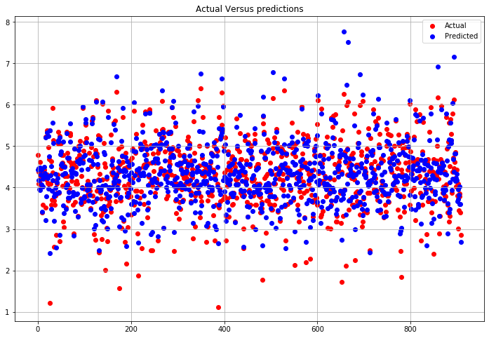

```python
x=np.arange(0,len(X_test),1)
fig, ax = plt.subplots(figsize=(12, 8))

plt.title('Actual Versus predictions', fontsize=12)
s1=plt.scatter(x, y_test,color='red')
s2=plt.scatter(x, y_predict, color='blue')
# produce a legend with the unique colors from the scatter
plt.legend([s1,s2],['Actual','Predicted'])
ax.grid(True)
plt.show()
```

```python
import sklearn.metrics as metrics
def regression_results(y_true, y_pred):

    # Regression metrics
    explained_variance=metrics.explained_variance_score(y_true, y_pred)
    mean_absolute_error=metrics.mean_absolute_error(y_true, y_pred)
    mse=metrics.mean_squared_error(y_true, y_pred)
    mean_squared_log_error=metrics.mean_squared_log_error(y_true, y_pred)
    median_absolute_error=metrics.median_absolute_error(y_true, y_pred)
    r2=metrics.r2_score(y_true, y_pred)

    print('explained_variance: ', round(explained_variance,4))
    print('mean_squared_log_error: ', round(mean_squared_log_error,4))
    print('r2: ', round(r2,4))
    print('MAE: ', round(mean_absolute_error,4))
    print('MSE: ', round(mse,4))
    print('RMSE: ', round(np.sqrt(mse),4))
```

```python
regression_results(y_test, y_predict)
```

```
explained_variance:  0.8969
mean_squared_log_error:  0.0035
r2:  0.8966
MAE:  0.1756
MSE:  0.066
RMSE:  0.2569
```

## Find the Co-relation with used_price for all the features

```python
df_columns = df.drop(['used_price'], axis=1)
df_used_price = df['used_price']
```

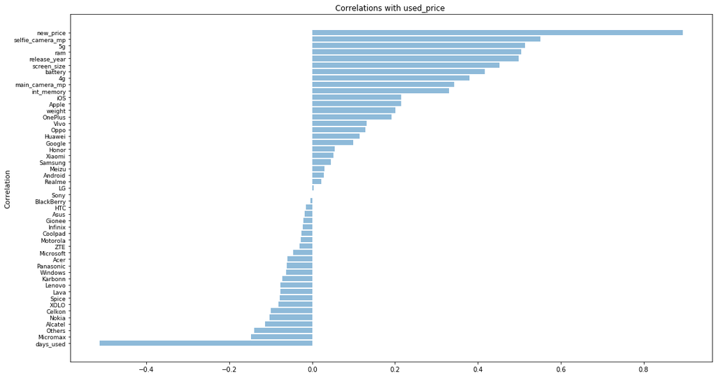

```python
df_corr= df_columns.corrwith(df_used_price)
df_corr.sort_values(inplace=True)
df_corr.index

df_columns.corrwith(df_used_price)

fig, ax = plt.subplots(figsize=(18, 10))
objects = df_corr.index
y_pos = np.arange(len(objects))
# this does not work
# correlation = [corr_open, corr_high, corr_low, corr_close, corr_volume]

plt.barh(df_corr.index, df_corr, align='center', alpha=0.5)
plt.ylabel('Correlation', fontsize=11)
plt.yticks(size = 9)
plt.title('Correlations with used_price ', fontsize=12)

plt.show()
```

```python
df_corr
```

```
days_used          -0.513341
Micromax           -0.147738
Others             -0.139705
Alcatel            -0.113075
Nokia              -0.102372
Celkon             -0.099159
XOLO               -0.080751
Spice              -0.078943
Lava               -0.077474
Lenovo             -0.076925
Karbonn            -0.072821
Windows            -0.062303
Panasonic          -0.061794
Acer               -0.059561
Microsoft          -0.046626
ZTE                -0.030657
Motorola           -0.027810
Coolpad            -0.026108
Infinix            -0.023031
Gionee             -0.021575
Asus               -0.017962
HTC                -0.014568
BlackBerry         -0.004229
Sony                0.000524
LG                  0.003769
Realme              0.021709
Android             0.027351
Meizu               0.030389
Samsung             0.045357
Xiaomi              0.050945
Honor               0.054651
Google              0.099173
Huawei              0.114056
Oppo                0.128880
Vivo                0.130761
OnePlus             0.192207
weight              0.200733
Apple               0.214056
iOS                 0.214056
int_memory          0.329568
main_camera_mp      0.342450
4g                  0.379923
battery             0.417073
screen_size         0.452047
release_year        0.497648
ram                 0.504781
5g                  0.514238
selfie_camera_mp    0.551190
new_price           0.894576
dtype: float64
```

## Feature Engineering

```python
df_corr = df [[ '4g', '5g',
       'selfie_camera_mp', 'int_memory', 'ram', 'battery',
        'days_used', 'new_price', 'Android','release_year',
      'iOS', 'Acer', 'Alcatel','Asus','BlackBerry', 'Coolpad',
        'Celkon',   'Gionee', 'Honor','Microsoft',  'Honor','HTC',
       'Huawei', 'Infinix', 'Karbonn', 'LG', 'Lava', 'Lenovo', 'Meizu',
       'Micromax', 'Motorola', 'Nokia', 'OnePlus', 'Oppo',
         'Panasonic', 'Realme', 'Samsung', 'Spice', 'Vivo',
       'XOLO', 'Xiaomi', 'ZTE' ]]
```

```python
df.columns
```

```
Index(['brand_name', 'os', 'screen_size', '4g', '5g', 'main_camera_mp',
       'selfie_camera_mp', 'int_memory', 'ram', 'battery', 'weight',
       'release_year', 'days_used', 'new_price', 'used_price', 'Android',
       'Others', 'Windows', 'iOS', 'Acer', 'Alcatel', 'Apple', 'Asus',
       'BlackBerry', 'Celkon', 'Coolpad', 'Gionee', 'Google', 'HTC', 'Honor',
       'Huawei', 'Infinix', 'Karbonn', 'LG', 'Lava', 'Lenovo', 'Meizu',
       'Micromax', 'Microsoft', 'Motorola', 'Nokia', 'OnePlus', 'Oppo',
       'Panasonic', 'Realme', 'Samsung', 'Sony', 'Spice', 'Vivo', 'XOLO',
       'Xiaomi', 'ZTE'],
      dtype='object')
```

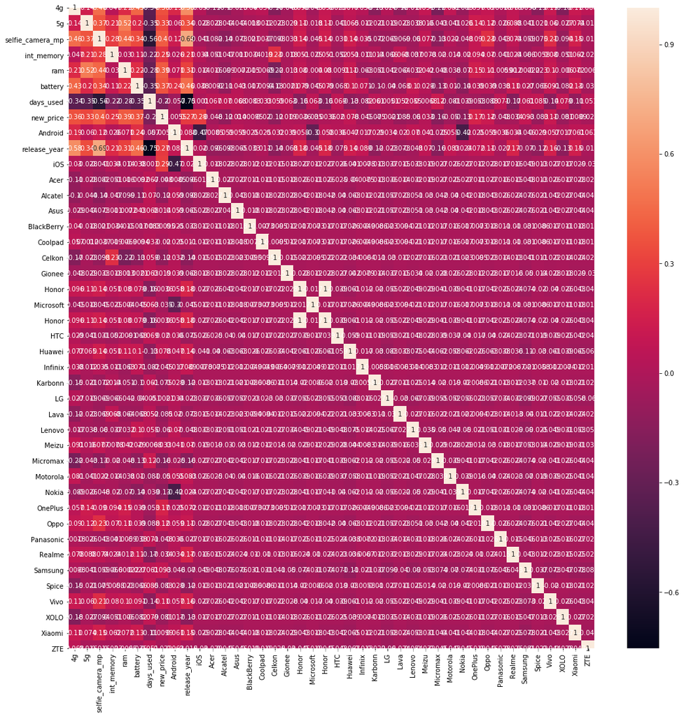

```python
corr = df_corr.corr()
fig, ax = plt.subplots(figsize=(18, 18))
sns.heatmap(corr,annot=True)
```

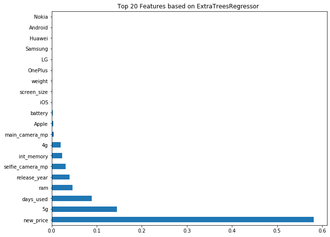

```python
X = df.drop(columns =['used_price','brand_name','os'])
y = df['used_price']
fig, ax = plt.subplots(figsize=(10, 8))
from sklearn.ensemble import ExtraTreesRegressor
import matplotlib.pyplot as plt
model = ExtraTreesRegressor()
model.fit(X,y)
plt.title('Top 20 Features based on ExtraTreesRegressor ', fontsize=12)
#print(model.feature_importances_) #use inbuilt class feature_importances of tree based classifiers
#plot graph of feature importances for better visualization
feat_importances = pd.Series(model.feature_importances_, index=X.columns)
feat_importances.nlargest(20).plot(kind='barh')
plt.show()
```

# New Model with Feature Engineering

```python
X = df[['4g', '5g',
       'selfie_camera_mp', 'int_memory', 'ram', 'battery',
          'new_price', 'Android', 'days_used',
      'iOS', 'Acer', 'Alcatel',
        'Celkon',   'Gionee', 'Honor',
       'Huawei', 'Infinix', 'Karbonn', 'LG', 'Lava', 'Lenovo', 'Meizu',
       'Micromax', 'Motorola', 'Nokia', 'OnePlus', 'Oppo',
        'Panasonic', 'Realme', 'Samsung', 'Spice', 'Vivo',
       'XOLO', 'Xiaomi', 'ZTE' ]]
# the dependent variable
#
#y = df[['used_price']]
y=np.log(df[['used_price']])
```

```python
X_train, X_test, y_train, y_test = train_test_split(X, y, test_size=0.30, random_state=1)
```

```python
from sklearn.preprocessing import StandardScaler
sc = StandardScaler()
X_train = sc.fit_transform(X_train)
X_test = sc.transform (X_test)
```

```python
regression_model2 = LinearRegression()
regression_model2.fit(X_train, y_train)
```

```
LinearRegression(copy_X=True, fit_intercept=True, n_jobs=None, normalize=False)
```

```python
y_predict2 = regression_model2.predict(X_test)
```

```python
from sklearn.metrics import mean_squared_error
import math

mse = mean_squared_error(y_test, y_predict2)

rmse = math.sqrt(mse)

print(rmse)
```

```
0.2845749618700535
```

```python
r2 = r2_score(y_test, y_predict2)
print('r2 score for perfect model is', r2)
```

```
r2 score for perfect model is 0.873129390636812
```

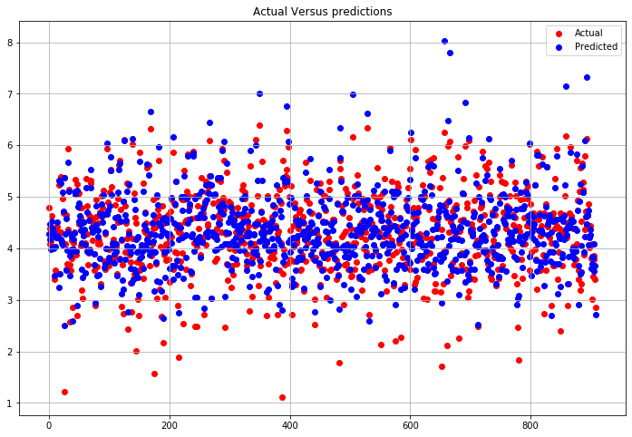

```python
x=np.arange(0,len(X_test),1)
fig, ax = plt.subplots(figsize=(12, 8))

plt.title('Actual Versus predictions', fontsize=12)
s1=plt.scatter(x, y_test,color='red')
s2=plt.scatter(x, y_predict2, color='blue')
# produce a legend with the unique colors from the scatter
plt.legend([s1,s2],['Actual','Predicted'])
ax.grid(True)
plt.show()
```

```python
regression_results(y_test, y_predict2)
```

```
explained_variance:  0.8736
mean_squared_log_error:  0.0042
r2:  0.8731
MAE:  0.1899
MSE:  0.081
RMSE:  0.2846
```

## Final Model Summary

The Previous model regression_model is better than regression_model2 , having less RMSE , MAE,MSE

```python
regression_results(y_test, y_predict)
```

```
explained_variance:  0.8969
mean_squared_log_error:  0.0035
r2:  0.8966
MAE:  0.1756
MSE:  0.066
RMSE:  0.2569
```

## Actionable Insights and Recommendations

Further more the feature engineering can be evaluated with other regression models ( Instead of simple linear regresssion model)